# Final Project: Mortality of COVID-19

Yufeng Zhu

12/15/2021

# 1 Introduction

Coronavirus disease 2019 (COVID-19) is an infectious illness caused by the SARS-CoV-2and can lead to severe acute respiratory syndrome. In December of 2019, the first case was discovered in Wuhan, China. Since then, the disease has spread globally, resulting in a pandemic that is still underway.

- COVID-19 is spread by inhaling contaminated air by viral droplets and tiny airborne particles. Individuals can inhale these droplets and particles, which can also settle on their eyes, noses, or mouths. People who are within 6 feet of an infected person are most likely to get the disease.
- Some common symptoms of COVID-19 are fever, cough, headache, breathing problems, and loss of smell and taste. After being exposed to the virus, symptoms might appear from one to fourteen days later.
- Several COVID-19 vaccines have been licensed and are being delivered in a number of countries that have begun mass immunization efforts. Physical or social separation, quarantining, indoor ventilation, covering coughs and sneezes, hand washing also help.

## 1.1 About the CDC Data

Provisional COVID-19 Deaths by Sex and Age

- In this dataset ,coronavirus disease 2019 (COVID-19) deaths were reported to NCHS by sex, age group, and incidence jurisdiction.
- Also note that the number of fatalities presented in this table represents the total number of deaths received and coded as of the analysis date, not all deaths that occurred during that time period. And due to the time lag between when a death occurs and when the death certificate is prepared, submitted to NCHS, and processed for reporting purposes, there is a delay between one to eight weeks or more.

# 2 Data Cleaning and Wrangling

```r
library(tidyverse)
library(readxl)
library(ggplot2)
library(dplyr)
library(tidyr)
library (janitor)
library(zoo)
library(gganimate)
library(data.table)
library(formattable)

Death_2021 <- read_csv("data-0XGPW.csv") %>% clean_names()
Covid_data_raw <- read_csv("Provisional_COVID-19_Deaths_by_Sex_and_Age.csv") %>% clean_names()
Covid_data_raw
```

```
## # A tibble: 71,604 x 16
##    data_as_of start_date end_date   group     year month state   sex   age_group
##    <chr>      <chr>      <chr>      <chr>    <dbl> <dbl> <chr>   <chr> <chr>
##  1 12/01/2021 01/01/2020 11/27/2021 By Total    NA    NA United~ All ~ All Ages
##  2 12/01/2021 01/01/2020 11/27/2021 By Total    NA    NA United~ All ~ Under 1 ~
##  3 12/01/2021 01/01/2020 11/27/2021 By Total    NA    NA United~ All ~ 0-17 yea~
##  4 12/01/2021 01/01/2020 11/27/2021 By Total    NA    NA United~ All ~ 1-4 years
##  5 12/01/2021 01/01/2020 11/27/2021 By Total    NA    NA United~ All ~ 5-14 yea~
##  6 12/01/2021 01/01/2020 11/27/2021 By Total    NA    NA United~ All ~ 15-24 ye~
##  7 12/01/2021 01/01/2020 11/27/2021 By Total    NA    NA United~ All ~ 18-29 ye~
##  8 12/01/2021 01/01/2020 11/27/2021 By Total    NA    NA United~ All ~ 25-34 ye~
##  9 12/01/2021 01/01/2020 11/27/2021 By Total    NA    NA United~ All ~ 30-39 ye~
## 10 12/01/2021 01/01/2020 11/27/2021 By Total    NA    NA United~ All ~ 35-44 ye~
## # ... with 71,594 more rows, and 7 more variables: covid_19_deaths <dbl>,
## #   total_deaths <dbl>, pneumonia_deaths <dbl>,
## #   pneumonia_and_covid_19_deaths <dbl>, influenza_deaths <dbl>,
## #   pneumonia_influenza_or_covid_19_deaths <dbl>, footnote <chr>
```

```r
Covid_data <- Covid_data_raw %>% select(start_date, end_date, state, sex, age_group, covid_19_deaths, total_deaths)
Covid_data
```

```
## # A tibble: 71,604 x 7
##    start_date end_date   state         sex       age_group covid_19_deaths total_deaths
##    <chr>      <chr>      <chr>         <chr>     <chr>               <dbl>        <dbl>
##  1 01/01/2020 11/27/2021 United States All Sexes All Ages           779402      6342417
##  2 01/01/2020 11/27/2021 United States All Sexes Under 1 ~             154        35779
##  3 01/01/2020 11/27/2021 United States All Sexes 0-17 yea~             630        63414
##  4 01/01/2020 11/27/2021 United States All Sexes 1-4 years              70         6649
##  5 01/01/2020 11/27/2021 United States All Sexes 5-14 yea~             200        10567
##  6 01/01/2020 11/27/2021 United States All Sexes 15-24 ye~            1922        68506
##  7 01/01/2020 11/27/2021 United States All Sexes 18-29 ye~            4618       120980
##  8 01/01/2020 11/27/2021 United States All Sexes 25-34 ye~            8318       143645
##  9 01/01/2020 11/27/2021 United States All Sexes 30-39 ye~           13638       176646
## 10 01/01/2020 11/27/2021 United States All Sexes 35-44 ye~           21061       210290
## # ... with 71,594 more rows
```

# 3 Data Analysis and Discussions

## 3.1 Mortality of COVID-19 Overall

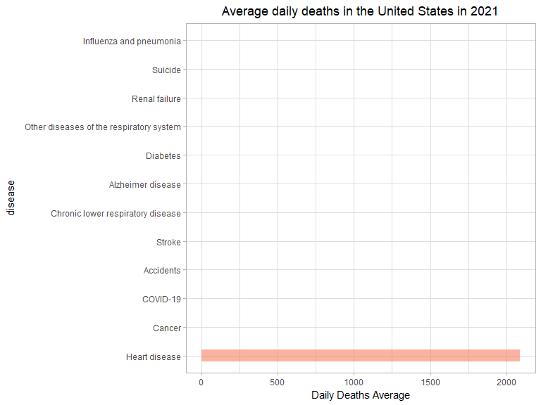

```r
p <- Death_2021 %>% mutate(disease = fct_reorder(disease, desc(daily_death_average))) %>%
  ggplot( aes(x=disease, y=daily_death_average)) +
    geom_bar(stat="identity", fill="#f68060", alpha=.6, width=.4) +
    coord_flip() + ylab("Daily Deaths Average") +theme_light() + ggtitle("Average daily deaths in the United States in 2021") + theme(plot.title = element_text(hjust =0.5)) + transition_states(disease) +
  shadow_mark() + enter_grow() + enter_fade()
animate(p, end_pause = 50)
```

Looking at the most recent data available on the average daily deaths in United States from COVID-19 and other causes, COVID-19 is the number 3 leading cause of death in the U.S. in 2021.

```r
Covid_data_Overall <- Covid_data %>% filter(sex=="All Sexes") %>%
  filter(state == "United States") %>% filter(age_group=="All Ages") %>% tail(23)  %>% mutate(time = as.yearmon(start_date, "%m/%d/%Y")) %>% select(start_date, end_date, time, covid_19_deaths)
formattable(Covid_data_Overall, align =c("l","c", "c", "r"))
```

| start_date | end_date | time | covid_19_deaths |
| --- | --- | --- | --- |
| 01/01/2020 | 01/31/2020 | Jan 2020 | 5 |
| 02/01/2020 | 02/29/2020 | Feb 2020 | 20 |
| 03/01/2020 | 03/31/2020 | Mar 2020 | 7161 |
| 04/01/2020 | 04/30/2020 | Apr 2020 | 65481 |
| 05/01/2020 | 05/31/2020 | May 2020 | 38300 |
| 06/01/2020 | 06/30/2020 | Jun 2020 | 18008 |
| 07/01/2020 | 07/31/2020 | Jul 2020 | 31116 |
| 08/01/2020 | 08/31/2020 | Aug 2020 | 29879 |
| 09/01/2020 | 09/30/2020 | Sep 2020 | 19139 |
| 10/01/2020 | 10/31/2020 | Oct 2020 | 24910 |
| 11/01/2020 | 11/30/2020 | Nov 2020 | 53219 |
| 12/01/2020 | 12/31/2020 | Dec 2020 | 98100 |
| 01/01/2021 | 01/31/2021 | Jan 2021 | 105341 |
| 02/01/2021 | 02/28/2021 | Feb 2021 | 48432 |
| 03/01/2021 | 03/31/2021 | Mar 2021 | 23146 |
| 04/01/2021 | 04/30/2021 | Apr 2021 | 18677 |
| 05/01/2021 | 05/31/2021 | May 2021 | 14875 |
| 06/01/2021 | 06/30/2021 | Jun 2021 | 7953 |
| 07/01/2021 | 07/31/2021 | Jul 2021 | 11111 |
| 08/01/2021 | 08/31/2021 | Aug 2021 | 47971 |
| 09/01/2021 | 09/30/2021 | Sep 2021 | 61612 |
| 10/01/2021 | 10/31/2021 | Oct 2021 | 40025 |
| 11/01/2021 | 11/27/2021 | Nov 2021 | 14921 |

[figure not shown]

```r
p0 <- ggplot(Covid_data_Overall, aes(x=time, y=covid_19_deaths)) + geom_point() + geom_line(aes(group=1)) +theme_light() + xlab("Time (month year)") + ylab("Covid-19 Deaths")  + ggtitle("Mortality of Covid-19 in USA from 2020 to 2021") + theme(plot.title = element_text(hjust =0.5)) + transition_reveal(as.numeric(time))
p0
animate(p0, end_pause = 50)
```

## 3.2 Mortality of COVID-19 by States

```r
require(ggrepel)
require(ggspatial)
require(sf)
require(rnaturalearth)
require(rnaturalearthdata)
library(usmap)
require(tools)

Covid_data_States <- Covid_data %>% filter(sex=="All Sexes") %>% subset(state!="United States") %>% filter(age_group=="All Ages") %>% filter(start_date=="01/01/2020") %>% filter(end_date=="11/27/2021")
Covid_data_States
```

```
## # A tibble: 53 x 7
##    start_date end_date   state     sex    age_group covid_19_deaths total_deaths
##    <chr>      <chr>      <chr>     <chr>  <chr>               <dbl>        <dbl>
##  1 01/01/2020 11/27/2021 Alabama   All S~ All Ages            15877       121980
##  2 01/01/2020 11/27/2021 Alaska    All S~ All Ages              888         9713
##  3 01/01/2020 11/27/2021 Arizona   All S~ All Ages            20331       147484
##  4 01/01/2020 11/27/2021 Arkansas  All S~ All Ages             8842        72758
##  5 01/01/2020 11/27/2021 Californ~ All S~ All Ages            77635       609666
##  6 01/01/2020 11/27/2021 Colorado  All S~ All Ages             9521        89239
##  7 01/01/2020 11/27/2021 Connecti~ All S~ All Ages             8919        66281
##  8 01/01/2020 11/27/2021 Delaware  All S~ All Ages             2139        20614
##  9 01/01/2020 11/27/2021 District~ All S~ All Ages             1627        13534
## 10 01/01/2020 11/27/2021 Florida   All S~ All Ages            59202       478737
## # ... with 43 more rows
```

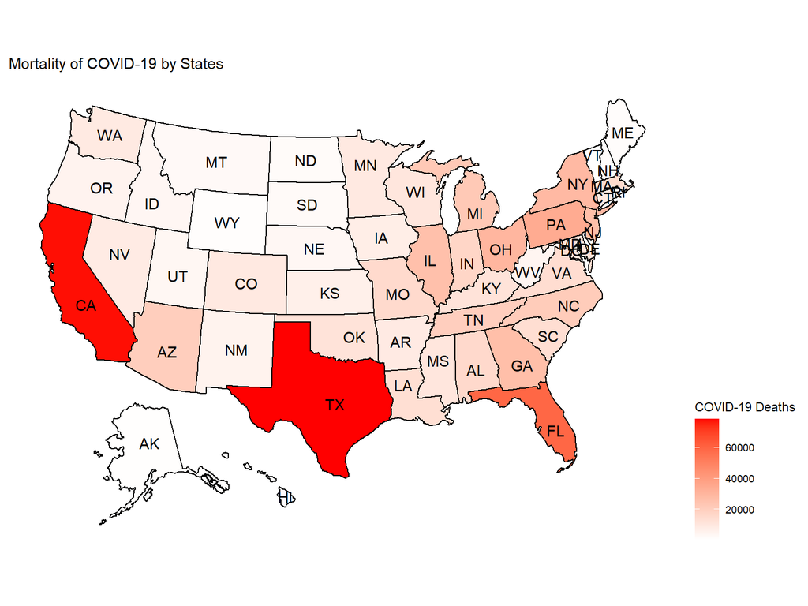

```r
plot_usmap(data=Covid_data_States, values="covid_19_deaths", labels = TRUE, label.size=3) +
  scale_fill_continuous(low = "white", high = "red", name = "COVID-19 Deaths") +
  theme(panel.background=element_blank(), legend.position = "right") +
  ggtitle("Mortality of COVID-19 by States")
```

As of December, 2021, the state with the highest number of COVID-19 cases was California. Around 50 million instances have been recorded across the United States, with California, Texas, and Florida reporting the most.

- Despite having a typically stricter approach to pandemic management, daily COVID cases in California appear to be higher than those in Texas or Florida.
  - California has had a proactive approach to the pandemic, having been the first state to announce plans for vaccine requirements for school students in October.

## 3.3 Mortality of COVID-19 by Sex

```r
Covid_data_Sex <- Covid_data %>% filter(age_group=="All Ages") %>% filter(state == "United States") %>% mutate(time = as.yearmon(start_date, "%m/%d/%Y")) %>% select(start_date, end_date, time, sex, covid_19_deaths) %>% tail(69)

Covid_data_Sex
```

```
## # A tibble: 69 x 5
##    start_date end_date   time      sex       covid_19_deaths
##    <chr>      <chr>      <yearmon> <chr>               <dbl>
##  1 01/01/2020 01/31/2020 Jan 2020  All Sexes               5
##  2 01/01/2020 01/31/2020 Jan 2020  Male                    2
##  3 01/01/2020 01/31/2020 Jan 2020  Female                  3
##  4 02/01/2020 02/29/2020 Feb 2020  All Sexes              20
##  5 02/01/2020 02/29/2020 Feb 2020  Male                   10
##  6 02/01/2020 02/29/2020 Feb 2020  Female                 10
##  7 03/01/2020 03/31/2020 Mar 2020  All Sexes            7161
##  8 03/01/2020 03/31/2020 Mar 2020  Male                 4370
##  9 03/01/2020 03/31/2020 Mar 2020  Female               2791
## 10 04/01/2020 04/30/2020 Apr 2020  All Sexes           65481
## # ... with 59 more rows
```

```r
p2 <- Covid_data_Sex %>%
  ggplot( aes(x=time, y=covid_19_deaths, group=sex, color=sex)) + geom_line() + geom_point()+theme_light() + xlab("Time (month year)") + ylab("Covid-19 Deaths")  + ggtitle("Mortality of Covid-19 in USA from 2020 to 2021 for different sex") + theme(plot.title = element_text(hjust =0.5))
```

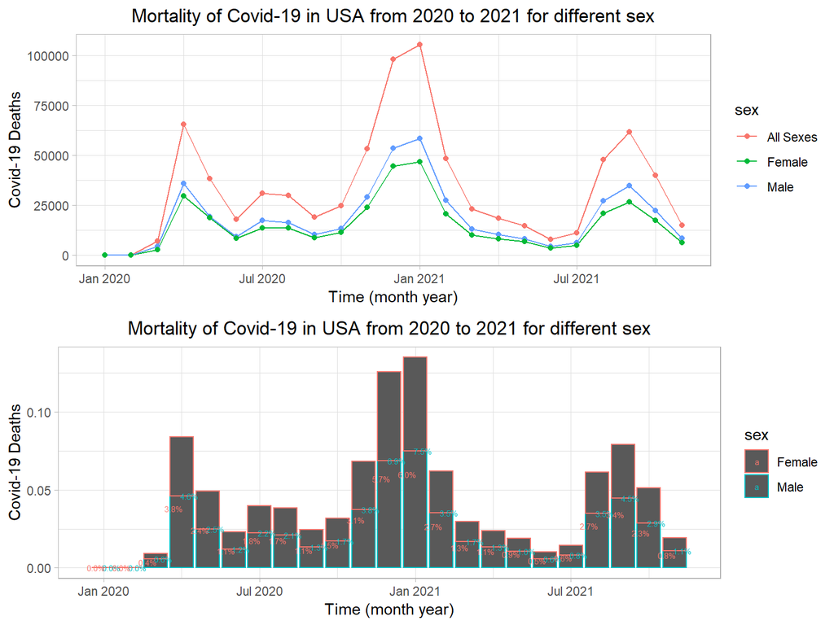

```r
Covid_data_Sex2 = Covid_data_Sex %>% subset(sex!="All Sexes") %>% mutate(pct = prop.table(covid_19_deaths))
p3 <- Covid_data_Sex2 %>% ggplot(aes(x = time, y = pct, fill(sex), color=sex, label = scales::percent(pct))) +
 geom_bar(stat='identity')  +theme_light() + xlab("Time (month year)") + ylab("Covid-19 Deaths")  + ggtitle("Mortality of Covid-19 in USA from 2020 to 2021 for different sex") + theme(plot.title = element_text(hjust =0.5))+
  geom_text(aes(label=paste0(sprintf("%1.1f", pct*100),"%")), size=2, position = position_dodge(.1))
require(gridExtra)
grid.arrange(p2, p3)
```

In the United States, men have a greater COVID-19 motality than women, which means men are more likely than women to be hospitalized to the intensive care unit (ICU) and to die in the ICU.

- According to one meta-analysis, males were more likely than women to get COVID-19 worldwide; there were roughly 55 men and 45 women per 100 infections (CI: 51.43–56.58).
- According to the Chinese Center for Disease Control and Prevention, males died at a rate of 2.8 percent, while women died at a rate of 1.7 percent.
- Why men are more vulnerable to COVID-19 than women?
  - Genetic: Higher expression of angiotensin-converting enzyme-2
  - Immunology: Sex-based immunological differences driven by sex hormone and X chromosome,
  - Gender behavior: higher levels of smoking and drinking
  - Less responsible attitude toward the pandemic

## 3.4 Mortality of COVID-19 by Age Group

```r
target <- c("All Ages","0-17 years", "18-29 years", "30-39 years", "40-49 years", "50-64 years", "65-74 years", "75-84 years", "85 years and over")
Covid_data_Ages <- Covid_data %>% filter(sex=="All Sexes") %>% filter(state == "United States") %>% mutate(time = as.yearmon(start_date, "%m/%d/%Y")) %>% select(start_date, end_date, time,age_group, covid_19_deaths) %>% tail (391) %>% subset( age_group!="All Ages"& age_group!="1-4 years" & age_group!= "15-24 years"& age_group!= "25-34 years"& age_group!= "35-44 years"& age_group!= "45-54 years"& age_group!= "5-14 years"& age_group!= "55-64 years"& age_group!= "Under 1 year")

Covid_data_Ages
```

```
## # A tibble: 184 x 5
##    start_date end_date   time      age_group         covid_19_deaths
##    <chr>      <chr>      <yearmon> <chr>                       <dbl>
##  1 01/01/2020 01/31/2020 Jan 2020  0-17 years                      0
##  2 01/01/2020 01/31/2020 Jan 2020  18-29 years                     0
##  3 01/01/2020 01/31/2020 Jan 2020  30-39 years                     0
##  4 01/01/2020 01/31/2020 Jan 2020  40-49 years                     0
##  5 01/01/2020 01/31/2020 Jan 2020  50-64 years                     2
##  6 01/01/2020 01/31/2020 Jan 2020  65-74 years                     1
##  7 01/01/2020 01/31/2020 Jan 2020  75-84 years                     2
##  8 01/01/2020 01/31/2020 Jan 2020  85 years and over               0
##  9 02/01/2020 02/29/2020 Feb 2020  0-17 years                      0
## 10 02/01/2020 02/29/2020 Feb 2020  18-29 years                     0
## # ... with 174 more rows
```

[figure not shown]

```r
p4 <- Covid_data_Ages %>% ggplot( aes(x=time, y=covid_19_deaths, group=age_group, color=age_group)) +  geom_line() + geom_point()+theme_light() + xlab("Time (month year)") + ylab("Covid-19 Deaths")  + ggtitle("Mortality of Covid-19 in USA from 2020 to 2021 for different age groups") + theme(plot.title = element_text(size=12)) + transition_reveal(as.numeric(time))
p4
animate(p4, end_pause = 50)
```

The mortality of COVID-19 in the age group over 50 years old appear to have a dramatic increase compared to the age group less than 50 years old, and 95 percent of Americans killed by COVID-19 were 50 or older.

- Although all age groups are at risk of getting COVID-19, older people face significant risk of developing severe illness as a result of physiological changes associated with aging and other underlying health issue, which means they might need hospitalization, intensive care, and a ventilator to help them breathe, otherwise they might even die.
- Why old people are more vulnerable to COVID-19 than young people?
  - Aging immune systems: accumulation of senescent cells that damage neighboring healthy cells and trigger inflammation
- Older people are more willing to get vaccinated, which is highly effective in preventing their COVID-19–associated hospitalizations.

# 4 Conclusions

- The mortality of COVID-19 is higher in the California by state, in males by sex, and in older adults over 50 years old by age group.
- California appears to have highest mortality regardless of its strict policy, which may due to the fact that it has more population proportionally in the older age group.
- The vaccination significantly reduces mortality of COVID-19, which is currently underway to immunize the world’s population.